# Eurofer Properties Database

- Abstract
- Introduction
- Section 1: Manufacturing & Heat Treatment
  - 1.1. Composition
  - 1.2. Heat Treatment
  - 1.3. Microstructure
  - 1.4. Product Forms
- Section 2: Thermo-physical Properties
  - 2.1. Density
  - 2.2. Thermal Diffusivity
  - 2.3. Specific Heat
  - 2.4. Thermal Conductivity
  - 2.5. Coefficient of Thermal Expansion
  - 2.6. Thermal Emissivity
  - 2.7. Electrical Resistivity
  - 2.8. Magnetic Properties
  - 2.9. Elastic Properties
- Section 3: Mechanical Properties

## Abstract

We present a comprehensive database for the ferritic-martensitic steel Eurofer97. The database is intended to assist in the mechanical design of components manufactured from reduced activation 9 Cr steels (e.g. Eurofer97), in particular, in a fusion reactor power source. The database is classified into three main categories: (1) fabrication and microstructure, (2) thermophysical properties, and (3) mechanical properties. The effects of irradiation (both neutron and ion) on the properties of Eurofer are also discussed. Data for each property is collected from various sources available in the public domain. The sources of data are given together with links to the original publication for verification or corrections. Various functional forms are developed to describe the properties of Eurofer97 as a function of temperature, and if available, as a function of the irradiation dose.

## Section 1: Manufacturing & Heat Treatment

### 1.1. Composition

[output not shown]

### 1.2. Heat Treatment

For a heat treatment sequence involving initial austenitization followed by a lower temperature tempering, example stages and their effects on the microstructure of ferritic/martensitic steel are as follows:

1. **Austenitizing: 979°C for 2 hours, followed by air cooling**
   - **Purpose**: This stage is aimed at fully austenitizing the steel, converting the initial microstructure (whether ferrite, pearlite, or a mix) to austenite. This high temperature ensures the dissolution of carbides and homogenizes the alloy elements within the steel matrix.
2. **Tempering: 739°C for 4 hours, followed by air cooling**
   - **Purpose**: The second stage is significantly lower than the first and serves to temper the martensitic structure formed after the first air cooling. Tempering at this temperature typically leads to a substantial transformation within the microstructure, focusing more on enhancing toughness and ductility while reducing hardness to a controlled extent compared to higher tempering temperatures.

#### Expected Microstructure

- **Tempered Martensite**: The quick cooling after the initial austenitization forms martensite, which is hard and brittle. The subsequent tempering at 739°C is essential for modifying this martensite. At this temperature, the martensitic structure undergoes significant changes:
  - **Carbide Precipitation**: Finer and more evenly distributed carbides form during this tempering stage. These carbides are crucial for increasing the toughness and wear resistance of the steel.
  - **Relaxation of Martensite**: The brittle martensitic lattice relaxes slightly, reducing internal stresses and thus decreasing the brittleness.
- **Potential Bainitic Transformation**: Depending on the specific alloying elements and their concentrations, tempering at this lower temperature (739°C) might also facilitate the formation of lower bainite. Bainite is a plate-like microstructure that offers a beneficial combination of strength and ductility. Its formation would depend significantly on the alloy composition and the actual cooling rate post-tempering.
- **Retained Austenite Stability**: At this lower tempering temperature, any retained austenite from the first cooling is more likely to remain stable or transform into bainite rather than converting into martensite, which can add to the ductility and toughness of the final product.

The image below depicts the expected microstructure of tempered martensitic steel. It shows finely dispersed carbides within a martensitic matrix, typical for steel that has been tempered at lower temperatures.

[figure not shown]

Fig.1 - Microstructure of tempered martensitic steel. It shows finely dispersed carbides within a martensitic matrix, typical for steel that has been tempered at lower temperatures.

3. **Aging: 600°C for 5000 hours**

**Long-term aging** at 600°C for 5000 hours is a specific type of annealing used primarily to understand and enhance the stability of ferritic/martensitic steels under prolonged thermal exposure. This process is particularly relevant in power generation and aerospace applications where components may experience elevated temperatures for extended periods.

##### Goals of the Annealing Process

1. **Stabilize the Microstructure**: Continuous exposure at 600°C aims to stabilize the microstructure against changes during future operational use.
2. **Optimize Mechanical Properties**: The process intends to balance ductility, toughness, and strength, making the steel suitable for long-term applications at high temperatures.

#### Expected Microstructural Changes

1. **Precipitation and Growth of Carbides**: At 600°C, you can expect the precipitation of various carbides, such as M<sub>23</sub>C<sub>6</sub> (where M can be Cr, Fe), and their growth or coalescence over the extended period. This affects the steel's hardness and tensile strength.
2. **Formation of Laves Phase**: In some ferritic/martensitic steels, especially those with high alloy content, a Fe<sub>2</sub>Mo-type Laves phase can form, which could influence creep resistance negatively by depleting the matrix of beneficial alloying elements like W and Mo.
3. **Spheroidization of Existing Carbides**: If the material has undergone previous treatments that formed pearlite or other lamellar structures, spheroidization might occur, leading to a more ductile microstructure.

#### Impact on Properties

- **Decrease in Hardness and Strength**: Due to the growth and coalescence of carbides, the material might lose some hardness and tensile strength.
- **Increase in Toughness and Ductility**: The spheroidization and stabilization processes tend to increase material ductility and fracture toughness, which are critical for components that undergo thermal cycling.
- **Potential Decrease in Creep Resistance**: The formation of Laves phases and the growth of large carbides can reduce the creep resistance, an essential factor for high-temperature applications.

### 1.3. Microstructure

[figure not shown]

Fig.2 - Orientation image maps from EBSD data of ODS-Eurofer steel austenitized at different temperatures (60×40 μm², step size 40 nm).

[figure not shown]

Fig.3 - Mean grain size dependence on austenitizing temperature.

Source of Figures: [Zilnyk2015](https://drive.google.com/file/d/1WtQjD-8v5ed6xC_1eBofhYG44xYSPt6v/view?usp=drive_link)

### 1.4. Product Forms

## Section 2: Thermophysical Properties

```python
%load_ext autoreload
%autoreload 2

import sys
sys.path.append('/path/to/Utilities')

from Utilities.models_1_2 import *
from Utilities.plots_1_1 import *


excel_filename = 'Eurofer/Eurofer_data_1_1.xlsx'
material_name = "Eurofer"

# Temperature range and initializations
T = np.arange(300, 1000, 10)
n = len(T)
RT = 273
f_size = 10
legend_size = 6
m_size = 60
```

### 2.1. Density

|  | EUROFER97TempK | EUROFER97DensityKg_m_3 |
| --- | --- | --- |
| 0 | 293 | 7750 |
| 1 | 373 | 7728 |
| 2 | 473 | 7699 |
| 3 | 573 | 7666 |
| 4 | 673 | 7633 |
| 5 | 773 | 7596 |
| 6 | 873 | 7558 |

Data source: [Tavassoli2004a](https://drive.google.com/file/d/1MIqQqASaKHNNw1S1WN10kY6QAHw2bBct/view?usp=drive_link)

**Fitting parameters for Eurofer Density**

```
[[Model]]
    Model(polynomial)
[[Fit Statistics]]
    # fitting method   = leastsq
    # function evals   = 16
    # data points      = 7
    # variables        = 4
    chi-square         = 0.93153508
    reduced chi-square = 0.31051169
    Akaike info crit   = -6.11782107
    Bayesian info crit = -6.33418047
    R-squared          = 0.99996842
[[Variables]]
    c0:  7815.18139 +/- 7.14476248 (0.09%) (init = 1)
    c1: -0.18035419 +/- 0.04145810 (22.99%) (init = 1)
    c2: -1.5050e-04 +/- 7.4870e-05 (49.75%) (init = 1)
    c3:  2.2447e-08 +/- 4.2592e-08 (189.75%) (init = 3)
[[Correlations]] (unreported correlations are < 0.100)
    C(c2, c3) = -0.9962
    C(c1, c2) = -0.9950
    C(c0, c1) = -0.9933
    C(c1, c3) = +0.9828
    C(c0, c2) = +0.9777
    C(c0, c3) = -0.9575
```

**The equation for Eurofer Density is:**

$\boxed{ + 7.815 \cdot 10^{3} - 1.804 \cdot 10^{-1} T - 1.505 \cdot 10^{-4} T^{2} + 2.245 \cdot 10^{-8} T^{3} }$

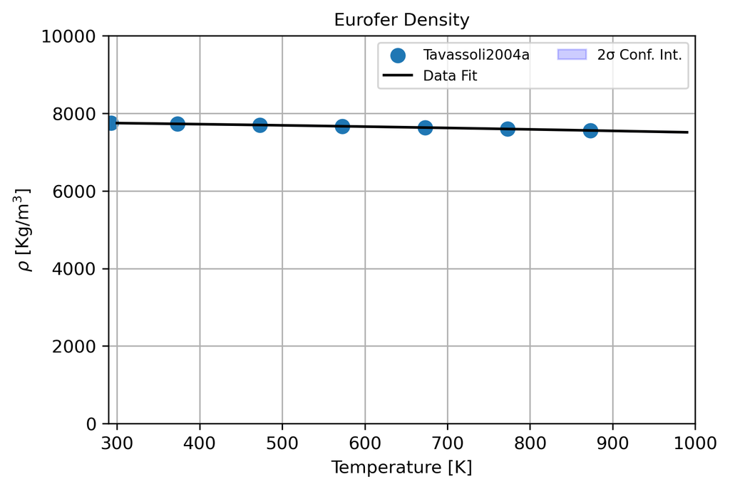

```python
# Load excel data for desired property name
material_property = "Density"
var_names, variables, dataframe = load_data(excel_filename, material_property, header_rows_list=[1, 3], num_data_rows=7)

x_label = 'Temperature [K]'
y_label = r'$\rho$ [Kg/m$^3$]'
x_lim = [290, 1000]
y_lim = [0, 10000]
data_labels = ['Tavassoli2004a']
display(Markdown('Data source: [Tavassoli2004a](https://drive.google.com/file/d/1MIqQqASaKHNNw1S1WN10kY6QAHw2bBct/view?usp=drive_link)'))

# Concatenate and sort data for fitting
vars_x = variables[::2]
vars_y = variables[1::2]
T_data, Y_data = concatenate_and_sort(vars_x, vars_y)
x_data_list = [x for x in vars_x]
y_data_list = vars_y
data_marker_sizes = [m_size] * len(x_data_list)

# Fit the data

p = [1, 1, 1, 1]
fit_result = get_model_fit_and_print_it(T_data, Y_data, fit_func='poly', param_initials=p, method='leastsq',\
    material_name=material_name, property_name=material_property, eq_digits=4, print_bool=True)

plot_data(x_data_list, y_data_list, T, fit_result, f_size, data_marker_sizes,\
          x_label, y_label, x_lim, y_lim, data_labels,\
          'Eurofer Density','best', legend_font_size= 8)

density_coef = [fit_result.params[key].value for key in fit_result.params]  # Extract parameter values as a list

# Define the polynomial function
def Density(T):
    return sum(density_coef[i] * T**i for i in range(len(density_coef)))
```

Data Source:Tavassoli 2004

### 2.2. Thermal Diffusivity

|  | EUROFER97MergiaTempK | EUROFER97MergiaThermalDiffusivityCoefcm2/s |
| --- | --- | --- |
| 0 | 295.595855 | 0.081641 |
| 1 | 322.797927 | 0.080790 |
| 2 | 373.316062 | 0.077536 |
| 3 | 472.797927 | 0.075784 |
| 4 | 573.056995 | 0.070729 |
| 5 | 673.316062 | 0.064822 |
| 6 | 772.797927 | 0.058014 |
| 7 | 873.056995 | 0.050256 |

Data source: [Megia2008](https://drive.google.com/file/d/1PJDQARGLnKBRXKxyHsmBi1k_AfUufuEY/view?usp=drive_link)

**Fitting parameters for Eurofer Diffusivity**

```
[[Model]]
    Model(polynomial)
[[Fit Statistics]]
    # fitting method   = leastsq
    # function evals   = 16
    # data points      = 8
    # variables        = 4
    chi-square         = 2.4812e-06
    reduced chi-square = 6.2029e-07
    Akaike info crit   = -111.889799
    Bayesian info crit = -111.572033
    R-squared          = 0.99725225
[[Variables]]
    c0:  0.08964800 +/- 0.01017097 (11.35%) (init = 1)
    c1: -2.8541e-05 +/- 5.9295e-05 (207.75%) (init = 1)
    c2:  1.2037e-08 +/- 1.0716e-07 (890.27%) (init = 1)
    c3: -3.5759e-11 +/- 6.0929e-11 (170.38%) (init = 3)
[[Correlations]] (unreported correlations are < 0.100)
    C(c2, c3) = -0.9965
    C(c1, c2) = -0.9957
    C(c0, c1) = -0.9950
    C(c1, c3) = +0.9847
    C(c0, c2) = +0.9822
    C(c0, c3) = -0.9646
```

**The equation for Eurofer Diffusivity is:**

$\boxed{ + 8.965 \cdot 10^{-2} - 2.854 \cdot 10^{-5} T + 1.204 \cdot 10^{-8} T^{2} - 3.576 \cdot 10^{-11} T^{3} }$

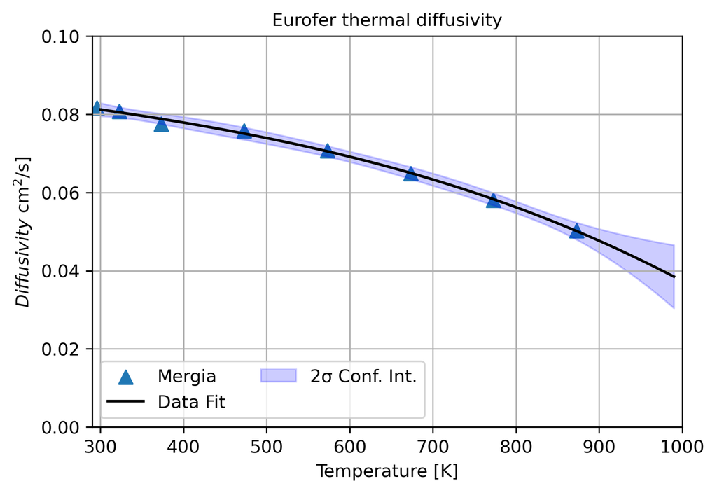

```python
material_property = "Diffusivity"
var_names, variables, dataframe = load_data(excel_filename, material_property, header_rows_list=[1, 3], num_data_rows=8)
x_label = 'Temperature [K]'
y_label = r'$Diffusivity$ cm$^2$/s]'
x_lim = [290, 1000]
y_lim = [0, 0.1]
data_labels = ['Mergia']
display(Markdown('Data source: [Megia2008](https://drive.google.com/file/d/1PJDQARGLnKBRXKxyHsmBi1k_AfUufuEY/view?usp=drive_link)'))


# Concatenate and sort data for fitting
vars_x = variables[::2]
vars_y = variables[1::2]
T_data, Y_data = concatenate_and_sort(vars_x, vars_y)
x_data_list = [x for x in vars_x]
y_data_list = vars_y
data_marker_sizes = [m_size] * len(x_data_list)

# Fit the data
p = [1, 1, 1, 1]
fit_result = get_model_fit_and_print_it(T_data, Y_data, fit_func='poly', param_initials=p, method='leastsq',\
    material_name=material_name, property_name=material_property, eq_digits=4, print_bool=True)

plot_data(x_data_list, y_data_list, T, fit_result, f_size, data_marker_sizes,\
          x_label, y_label, x_lim, y_lim, data_labels,\
          'Eurofer thermal diffusivity','lower left', legend_font_size= 10)
diffusivity_coef = [fit_result.params[key].value for key in fit_result.params]  # Extract parameter values as a list

# Define the polynomial function
def ThermalDiffusivity(T):
    return sum(diffusivity_coef[i] * T**i for i in range(len(diffusivity_coef)))
```

### 2.3. Specific Heat

|  | Mergia2008TempK | Mergia2008SpecificHeatJ/kgK | Chun2015TempK | Chun2015SpecificHeatJ/kgK |
| --- | --- | --- | --- | --- |
| 0 | 296.103896 | 448.395379 | 293.54795 | 454.68159 |
| 1 | 322.727273 | 461.489089 | 326.42466 | 467.34914 |
| 2 | 348.051948 | 475.353017 | 373.00000 | 488.52065 |
| 3 | 373.376623 | 485.365854 | 425.05479 | 509.65287 |
| 4 | 398.051948 | 496.148909 | 474.36986 | 522.20258 |
| 5 | 423.376623 | 504.621309 | 523.68493 | 543.35445 |
| 6 | 447.402597 | 513.863928 | 573.00000 | 551.60308 |
| 7 | 472.727273 | 521.566110 | 622.31507 | 572.75495 |
| 8 | 498.051948 | 530.038511 | 671.63014 | 585.30466 |
| 9 | 522.727273 | 536.970475 | 723.68493 | 610.73796 |
| 10 | 548.051948 | 544.672657 | 773.00000 | 653.39520 |
| 11 | 572.727273 | 550.834403 | 822.31507 | 721.85889 |
| 12 | 598.051948 | 556.996149 | 871.63014 | 803.22581 |
| 13 | 622.727273 | 565.468549 | 920.94521 | 901.79702 |
| 14 | 648.051948 | 573.170732 | 973.00000 | 1026.15505 |
| 15 | 673.376623 | 583.953787 | NaN | NaN |
| 16 | 698.051948 | 597.047497 | NaN | NaN |
| 17 | 722.727273 | 611.681643 | NaN | NaN |
| 18 | 747.402597 | 628.626444 | NaN | NaN |
| 19 | 773.376623 | 655.584082 | NaN | NaN |
| 20 | 797.402597 | 687.163030 | NaN | NaN |
| 21 | 822.727273 | 721.052632 | NaN | NaN |
| 22 | 847.402597 | 764.184852 | NaN | NaN |
| 23 | 872.727273 | 801.155327 | NaN | NaN |

Data sources: [Megia2008](https://drive.google.com/file/d/1PJDQARGLnKBRXKxyHsmBi1k_AfUufuEY/view?usp=drive_link), [Chun2015](https://drive.google.com/file/d/1QxovNvh7x0Sc-3EJGdv9H9zT2BlxhsmZ/view?usp=drive_link)

**Fitting parameters for Eurofer Specific Heat**

```
[[Model]]
    Model(polynomial)
[[Fit Statistics]]
    # fitting method   = leastsq
    # function evals   = 16
    # data points      = 39
    # variables        = 4
    chi-square         = 883.943790
    reduced chi-square = 25.2555369
    Akaike info crit   = 129.712441
    Bayesian info crit = 136.366688
    R-squared          = 0.99857268
[[Variables]]
    c0: -116.692873 +/- 26.0385679 (22.31%) (init = 1)
    c1:  3.37274344 +/- 0.14033902 (4.16%) (init = 1)
    c2: -0.00617055 +/- 2.3728e-04 (3.85%) (init = 1)
    c3:  4.0223e-06 +/- 1.2721e-07 (3.16%) (init = 3)
[[Correlations]] (unreported correlations are < 0.100)
    C(c2, c3) = -0.9950
    C(c1, c2) = -0.9939
    C(c0, c1) = -0.9920
    C(c1, c3) = +0.9785
    C(c0, c2) = +0.9732
    C(c0, c3) = -0.9479
```

**The equation for Eurofer Specific Heat is:**

$\boxed{ -1.167 \cdot 10^{2} + 3.373 T - 6.171 \cdot 10^{-3} T^{2} + 4.022 \cdot 10^{-6} T^{3} }$

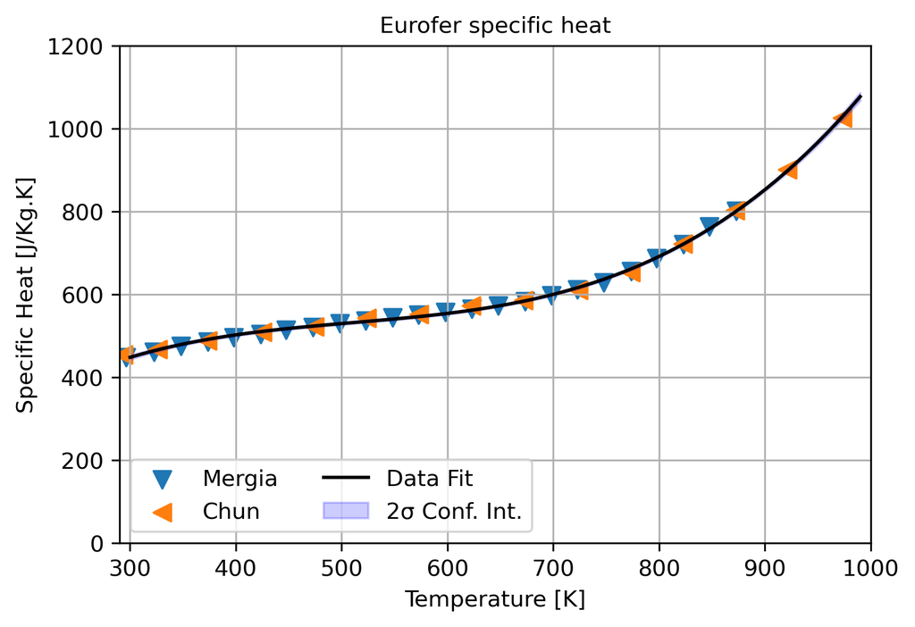

```python
material_property = "Specific Heat"
var_names, variables, df = load_data(excel_filename, material_property, header_rows_list=[1, 3], num_data_rows=24)
x_label = 'Temperature [K]'
y_label = r'Specific Heat [J/Kg.K]'
x_lim = [290, 1000]
y_lim = [0, 1200]
data_labels = ['Mergia','Chun']
display(Markdown('Data sources: [Megia2008](https://drive.google.com/file/d/1PJDQARGLnKBRXKxyHsmBi1k_AfUufuEY/view?usp=drive_link), [Chun2015](https://drive.google.com/file/d/1QxovNvh7x0Sc-3EJGdv9H9zT2BlxhsmZ/view?usp=drive_link)'))

# Concatenate and sort data for fitting?
vars_x = variables[::2]
vars_y = variables[1::2]
T_data, Y_data = concatenate_and_sort(vars_x, vars_y)
x_data_list = [x for x in vars_x]
y_data_list = vars_y
data_marker_sizes = [m_size] * len(x_data_list)

# Fit the data
p = [1, 1, 1, 1]
fit_result = get_model_fit_and_print_it(T_data, Y_data, fit_func='poly', param_initials=p, method='leastsq',\
    material_name=material_name, property_name=material_property, eq_digits=4, print_bool=True)

plot_data(x_data_list, y_data_list, T, fit_result, f_size, data_marker_sizes,\
          x_label, y_label, x_lim, y_lim, data_labels,\
          'Eurofer specific heat','lower left', legend_font_size= 10)

cp_coef = [fit_result.params[key].value for key in fit_result.params]  # Extract parameter values as a list

# Define the polynomial function
def SpecificHeat(T):
    return sum(cp_coef[i] * T**i for i in range(len(cp_coef)))
```

### 2.4. Conductivity

|  | Mergia2008TempK | Mergia2008ThermalConductivitykW/mK | Chun2015TempK1 | Chun2015ThermalConductivityW/mK |
| --- | --- | --- | --- | --- |
| 0 | 295.833333 | 28.330097 | 293.54795 | 28.15894 |
| 1 | 322.619048 | 28.932039 | 323.68493 | 28.88742 |
| 2 | 372.619048 | 29.194175 | 375.73973 | 29.74834 |
| 3 | 473.214286 | 30.669903 | 425.05479 | 30.27815 |
| 4 | 572.619048 | 30.194175 | 474.36986 | 30.34437 |
| 5 | 672.619048 | 29.330097 | 526.42466 | 30.21192 |
| 6 | 772.619048 | 29.446602 | 573.00000 | 29.94702 |
| 7 | 872.619048 | 31.174757 | 625.05479 | 29.68212 |
| 8 | NaN | NaN | 674.36986 | 29.48344 |
| 9 | NaN | NaN | 723.68493 | 29.35099 |
| 10 | NaN | NaN | 775.73973 | 29.61589 |
| 11 | NaN | NaN | 825.05479 | 30.07947 |
| 12 | NaN | NaN | 874.36986 | 31.13907 |

Data sources: [Megia2008](https://drive.google.com/file/d/1PJDQARGLnKBRXKxyHsmBi1k_AfUufuEY/view?usp=drive_link), [Chun2015](https://drive.google.com/file/d/1QxovNvh7x0Sc-3EJGdv9H9zT2BlxhsmZ/view?usp=drive_link)

**Fitting parameters for Eurofer Conductivity**

```
[[Model]]
    Model(polynomial)
[[Fit Statistics]]
    # fitting method   = leastsq
    # function evals   = 16
    # data points      = 21
    # variables        = 4
    chi-square         = 0.55241752
    reduced chi-square = 0.03249515
    Akaike info crit   = -68.3974451
    Bayesian info crit = -64.2193553
    R-squared          = 0.95674888
[[Variables]]
    c0:  5.87583881 +/- 1.45053551 (24.69%) (init = 1)
    c1:  0.13326278 +/- 0.00839406 (6.30%) (init = 1)
    c2: -2.3475e-04 +/- 1.5154e-05 (6.46%) (init = 1)
    c3:  1.3195e-07 +/- 8.6392e-09 (6.55%) (init = 3)
[[Correlations]] (unreported correlations are < 0.100)
    C(c2, c3) = -0.9964
    C(c1, c2) = -0.9954
    C(c0, c1) = -0.9942
    C(c1, c3) = +0.9839
    C(c0, c2) = +0.9802
    C(c0, c3) = -0.9613
```

**The equation for Eurofer Conductivity is:**

$\boxed{ + 5.876 + 1.333 \cdot 10^{-1} T - 2.348 \cdot 10^{-4} T^{2} + 1.32 \cdot 10^{-7} T^{3} }$

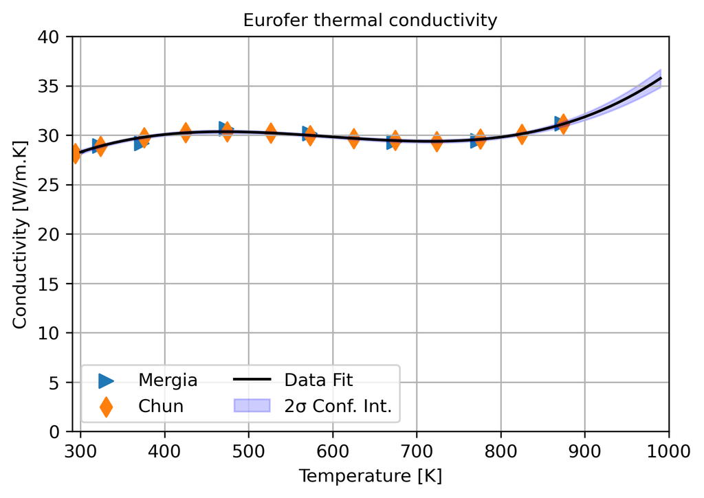

```python
material_property = "Conductivity"
var_names, variables, dataframe = load_data(excel_filename, material_property, header_rows_list=[1, 3], num_data_rows=13)
x_label ='Temperature [K]'
y_label =r'Conductivity [W/m.K]'
x_lim = [290, 1000]
y_lim = [0, 40]
data_labels = ['Mergia','Chun']
display(Markdown('Data sources: [Megia2008](https://drive.google.com/file/d/1PJDQARGLnKBRXKxyHsmBi1k_AfUufuEY/view?usp=drive_link), [Chun2015](https://drive.google.com/file/d/1QxovNvh7x0Sc-3EJGdv9H9zT2BlxhsmZ/view?usp=drive_link)'))

# Concatenate and sort data for fitting
vars_x = variables[::2]
vars_y = variables[1::2]
T_data, Y_data = concatenate_and_sort(vars_x, vars_y)
x_data_list = [x for x in vars_x]
y_data_list = vars_y
data_marker_sizes = [m_size] * len(x_data_list)

# Fit the data
p = [1, 1, 1, 1]
fit_result = get_model_fit_and_print_it(T_data, Y_data, fit_func='poly', param_initials=p, method='leastsq',\
    material_name=material_name, property_name=material_property, eq_digits=4, print_bool=True)

plot_data(x_data_list, y_data_list, T, fit_result, f_size, data_marker_sizes,\
          x_label, y_label, x_lim, y_lim, data_labels,\
          'Eurofer thermal conductivity','lower left', legend_font_size= 10)

k_coeff = [fit_result.params[key].value for key in fit_result.params]  # Extract parameter values as a list

# Define the polynomial function
def ThermalConductivity(T):
    return sum(k_coeff[i] * T**i for i in range(len(k_coeff)))
```

### 2.5. Resistivity

|  | EUROFER97MergiaTempK | EUROFER97MergiaElectricalResistivityx108ohmm | Tavassoli2004TempK | Tavassoli2004ElectricalResistivityx108ohmm1 |
| --- | --- | --- | --- | --- |
| 0 | 303.317972 | 51.077844 | 293.0 | 50.0 |
| 1 | 327.649770 | 54.550898 | 323.0 | 54.0 |
| 2 | 344.239631 | 56.467066 | 373.0 | 60.0 |
| 3 | 365.806452 | 59.101796 | 423.0 | 67.0 |
| 4 | 396.221198 | 62.814371 | 473.0 | 74.0 |
| 5 | 423.317972 | 66.407186 | 523.0 | 80.0 |
| 6 | 450.414747 | 69.281437 | 573.0 | 87.0 |
| 7 | 467.004608 | 71.437126 | 623.0 | 93.0 |
| 8 | 497.419355 | 75.508982 | 673.0 | 100.0 |
| 9 | 523.410138 | 77.425150 | 723.0 | 107.0 |
| 10 | 545.529954 | 81.137725 | 773.0 | 113.0 |
| 11 | 577.050691 | 84.730539 | 823.0 | 120.0 |
| 12 | 601.935484 | 87.245509 | 873.0 | 127.0 |
| 13 | 657.788018 | 93.473054 | 923.0 | 133.0 |
| 14 | 682.119816 | 96.227545 | NaN | NaN |
| 15 | 708.110599 | 99.580838 | NaN | NaN |
| 16 | 734.654378 | 102.574850 | NaN | NaN |
| 17 | 763.410138 | 105.808383 | NaN | NaN |
| 18 | 783.870968 | 107.964072 | NaN | NaN |
| 19 | 817.050691 | 111.197605 | NaN | NaN |
| 20 | 850.230415 | 114.191617 | NaN | NaN |
| 21 | 883.963134 | 117.425150 | NaN | NaN |
| 22 | 924.884793 | 121.377246 | NaN | NaN |

Data sources: [Megia2008](https://drive.google.com/file/d/1PJDQARGLnKBRXKxyHsmBi1k_AfUufuEY/view?usp=drive_link),[Tavassoli2004a](https://drive.google.com/file/d/1MIqQqASaKHNNw1S1WN10kY6QAHw2bBct/view?usp=drive_link)

**Fitting parameters for Eurofer Resistivity**

```
[[Model]]
    Model(polynomial)
[[Fit Statistics]]
    # fitting method   = leastsq
    # function evals   = 16
    # data points      = 37
    # variables        = 4
    chi-square         = 260.704805
    reduced chi-square = 7.90014562
    Akaike info crit   = 80.2414211
    Bayesian info crit = 86.6850928
    R-squared          = 0.98729654
[[Variables]]
    c0:  10.6916862 +/- 16.4202729 (153.58%) (init = 1)
    c1:  0.13909592 +/- 0.09008117 (64.76%) (init = 1)
    c2: -1.9320e-05 +/- 1.5520e-04 (803.33%) (init = 1)
    c3:  5.1583e-09 +/- 8.4775e-08 (1643.47%) (init = 3)
[[Correlations]] (unreported correlations are < 0.100)
    C(c2, c3) = -0.9957
    C(c1, c2) = -0.9946
    C(c0, c1) = -0.9930
    C(c1, c3) = +0.9810
    C(c0, c2) = +0.9762
    C(c0, c3) = -0.9540
```

**The equation for Eurofer Resistivity is:**

$\boxed{ + 1.069 \cdot 10^{1} + 1.391 \cdot 10^{-1} T - 1.932 \cdot 10^{-5} T^{2} + 5.158 \cdot 10^{-9} T^{3} }$

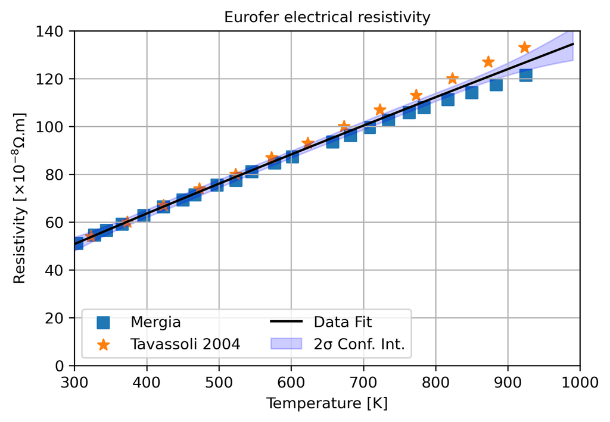

```python
material_property = "Resistivity"
var_names, variables, df = load_data(excel_filename, material_property, header_rows_list=[1, 3], num_data_rows=23)
x_label='Temperature [K]'
y_label=r'Resistivity [$\times 10^{-8} \Omega$.m]'
x_lim=[300, 1000]
y_lim=[0, 140]
data_labels = ['Mergia', 'Tavassoli 2004']
display(Markdown('Data sources: [Megia2008](https://drive.google.com/file/d/1PJDQARGLnKBRXKxyHsmBi1k_AfUufuEY/view?usp=drive_link),\
[Tavassoli2004a](https://drive.google.com/file/d/1MIqQqASaKHNNw1S1WN10kY6QAHw2bBct/view?usp=drive_link)'))

# Concatenate and sort data for fitting
vars_x = variables[::2]
vars_y = variables[1::2]
T_data, Y_data = concatenate_and_sort(vars_x, vars_y)
x_data_list = [x for x in vars_x]
y_data_list = vars_y
data_marker_sizes = [m_size] * len(x_data_list)

# Fit the data
p = [1, 1, 1, 1]
fit_result = get_model_fit_and_print_it(T_data, Y_data, fit_func='poly', param_initials=p, method='leastsq',\
    material_name=material_name, property_name=material_property, eq_digits=4, print_bool=True)

plot_data(x_data_list, y_data_list, T, fit_result, f_size, data_marker_sizes,\
          x_label, y_label, x_lim, y_lim, data_labels,\
          'Eurofer electrical resistivity','lower left', legend_font_size= 10)

rho_coeff = [fit_result.params[key].value for key in fit_result.params]  # Extract parameter values as a list

# Define the polynomial function
def ElectricalResistivity(T):
    return sum(rho_coeff[i] * T**i for i in range(len(rho_coeff)))
```

### 2.6. CTE

|  | EUROFER97TempC | EUROFER97CoefficientofThermalExpansion |
| --- | --- | --- |
| 0 | 100 | 10.689873 |
| 1 | 200 | 11.044304 |
| 2 | 300 | 11.386076 |
| 3 | 400 | 11.696203 |
| 4 | 500 | 11.987342 |
| 5 | 600 | 12.246835 |
| 6 | 700 | 12.487342 |

Data source: [Chun2015](https://drive.google.com/file/d/1QxovNvh7x0Sc-3EJGdv9H9zT2BlxhsmZ/view?usp=drive_link)

**Fitting parameters for Eurofer CTE**

```
[[Model]]
    Model(polynomial)
[[Fit Statistics]]
    # fitting method   = leastsq
    # function evals   = 16
    # data points      = 7
    # variables        = 4
    chi-square         = 2.5751e-05
    reduced chi-square = 8.5838e-06
    Akaike info crit   = -79.5905308
    Bayesian info crit = -79.8068902
    R-squared          = 0.99998983
[[Variables]]
    c0:  10.3092224 +/- 0.00850583 (0.08%) (init = 1)
    c1:  0.00389793 +/- 8.5819e-05 (2.20%) (init = 1)
    c2: -1.0021e-06 +/- 2.4134e-07 (24.08%) (init = 1)
    c3: -1.7581e-10 +/- 1.9935e-10 (113.39%) (init = 3)
[[Correlations]] (unreported correlations are < 0.100)
    C(c2, c3) = -0.9912
    C(c1, c2) = -0.9835
    C(c0, c1) = -0.9547
    C(c1, c3) = +0.9524
    C(c0, c2) = +0.8960
    C(c0, c3) = -0.8437
```

**The equation for Eurofer CTE is:**

$\boxed{ + 1.031 \cdot 10^{1} + 3.898 \cdot 10^{-3} T - 1.002 \cdot 10^{-6} T^{2} - 1.758 \cdot 10^{-10} T^{3} }$

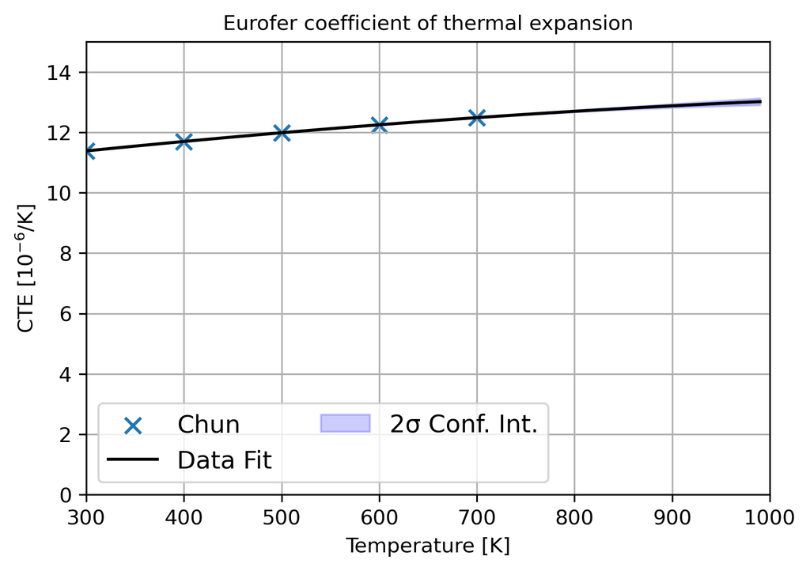

```python
material_property = "CTE"
var_names, variables, dataframe = load_data(excel_filename, material_property, header_rows_list=[1, 3], num_data_rows=7)

x_label='Temperature [K]'
y_label=r'CTE [$10^{-6}$/K]'
x_lim=[300, 1000]
y_lim=[0, 15]
data_labels = ['Chun']
display(Markdown('Data source: [Chun2015](https://drive.google.com/file/d/1QxovNvh7x0Sc-3EJGdv9H9zT2BlxhsmZ/view?usp=drive_link)'))


# Concatenate and sort data for fitting
vars_x = variables[::2]
vars_y = variables[1::2]
T_data, Y_data = concatenate_and_sort(vars_x, vars_y)
x_data_list = [x for x in vars_x]
y_data_list = vars_y
data_marker_sizes = [m_size] * len(x_data_list)

# Fit the data
p = [1, 1, 1, 1]
fit_result = get_model_fit_and_print_it(T_data, Y_data, fit_func='poly', param_initials=p, method='leastsq',\
    material_name=material_name, property_name=material_property, eq_digits=4, print_bool=True)

plot_data(x_data_list, y_data_list, T, fit_result, f_size, data_marker_sizes,\
          x_label, y_label, x_lim, y_lim, data_labels,\
          'Eurofer coefficient of thermal expansion','lower left', legend_font_size= 12)

CTE_coef = [fit_result.params[key].value for key in fit_result.params]  # Extract parameter values as a list

# Define the polynomial function
def CTE(T):
    return sum(CTE_coef[i] * T**i for i in range(len(CTE_coef)))
```

### 2.7. Emissivity

|  | Echaniz2021AsrolledTempK | Echaniz2021AsrolledHemisphericalEmissivity | Echaniz2021PolishedTempK1 | Echaniz2021PolishedHemisphericalEmissivity1 | Echaniz2021polishedTempK2 | Echaniz2021polishedNormalEmissivity |
| --- | --- | --- | --- | --- | --- | --- |
| 0 | 473.100872 | 0.180080 | 430.136986 | 0.116901 | 423 | 0.083535 |
| 1 | 573.225405 | 0.214688 | 524.283935 | 0.128974 | 523 | 0.100909 |
| 2 | 672.976339 | 0.245272 | 624.034869 | 0.142656 | 623 | 0.120303 |
| 3 | 772.727273 | 0.273843 | 724.906600 | 0.156338 | 723 | 0.140707 |
| 4 | 872.851806 | 0.302012 | 820.921544 | 0.176459 | 823 | 0.162929 |

Data source: [Echaniz2021](https://drive.google.com/file/d/1R--IcJwy-Frr6Qgmk2nLzMMtuwO5uZSP/view?usp=sharing)

**Fitting parameters for Eurofer Emissivity**

```
[[Model]]
    Model(polynomial)
[[Fit Statistics]]
    # fitting method   = leastsq
    # function evals   = 13
    # data points      = 5
    # variables        = 3
    chi-square         = 5.1307e-08
    reduced chi-square = 2.5653e-08
    Akaike info crit   = -85.9744103
    Bayesian info crit = -87.1460965
[[Variables]]
    c0:  0.02611194 +/- 0.00160870 (6.16%) (init = 1)
    c1:  1.0329e-04 +/- 5.3577e-06 (5.19%) (init = 1)
    c2:  7.6479e-08 +/- 4.2806e-09 (5.60%) (init = 2)
[[Correlations]] (unreported correlations are < 0.100)
    C(c1, c2) = -0.9955
    C(c0, c1) = -0.9937
    C(c0, c2) = +0.9796
```

**The equation for Eurofer Emissivity is:**

$\boxed{ + 2.611 \cdot 10^{-2} + 1.033 \cdot 10^{-4} T + 7.648 \cdot 10^{-8} T^{2} }$

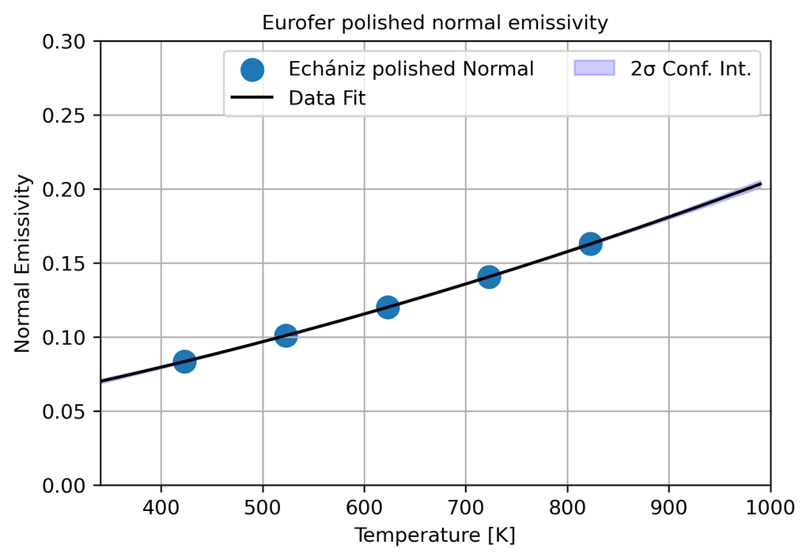

```python
material_property = "Emissivity"
var_names, variables, dataframe = load_data(excel_filename, material_property, header_rows_list=[1, 3], num_data_rows=5)
x_label = 'Temperature [K]'
y_label = r'Normal Emissivity'
x_lim=[340, 1000]
y_lim=[0, 0.3]
data_labels = ['Echániz polished Normal']
display(Markdown('Data source: [Echaniz2021](https://drive.google.com/file/d/1R--IcJwy-Frr6Qgmk2nLzMMtuwO5uZSP/view?usp=sharing)'))

vars_x = variables[::2]
vars_y = variables[1::2]

# Creating lists with only the first column
x_data_list = [vars_x[2]]
y_data_list = [vars_y[2]]
# Extract only the third element from vars_x and vars_y
T_data = x_data_list
Y_data = y_data_list
data_marker_sizes = [2*m_size] * len(x_data_list)

# Fit the data
p = [1, 1, 1]
fit_result = get_model_fit_and_print_it(T_data, Y_data, fit_func='poly', param_initials=p, method='leastsq',\
    material_name=material_name, property_name=material_property, eq_digits=4, print_bool=True)

plot_data(x_data_list, y_data_list, T, fit_result, f_size, data_marker_sizes,\
          x_label, y_label, x_lim, y_lim, data_labels,\
          'Eurofer polished normal emissivity','best', legend_font_size= 10)

emit1_coef = [fit_result.params[key].value for key in fit_result.params]  # Extract parameter values as a list

# Define the polynomial function
def NormalEmissivity(T):
    return sum(emit1_coef[i] * T**i for i in range(len(emit1_coef)))
```

|  | Echaniz2021AsrolledTempK | Echaniz2021AsrolledHemisphericalEmissivity | Echaniz2021PolishedTempK1 | Echaniz2021PolishedHemisphericalEmissivity1 | Echaniz2021polishedTempK2 | Echaniz2021polishedNormalEmissivity |
| --- | --- | --- | --- | --- | --- | --- |
| 0 | 473.100872 | 0.180080 | 430.136986 | 0.116901 | 423 | 0.083535 |
| 1 | 573.225405 | 0.214688 | 524.283935 | 0.128974 | 523 | 0.100909 |
| 2 | 672.976339 | 0.245272 | 624.034869 | 0.142656 | 623 | 0.120303 |
| 3 | 772.727273 | 0.273843 | 724.906600 | 0.156338 | 723 | 0.140707 |
| 4 | 872.851806 | 0.302012 | 820.921544 | 0.176459 | 823 | 0.162929 |

Data source: [Echaniz2021](https://drive.google.com/file/d/1R--IcJwy-Frr6Qgmk2nLzMMtuwO5uZSP/view?usp=sharing)

**Fitting parameters for Eurofer Emissivity**

```
[[Model]]
    Model(polynomial)
[[Fit Statistics]]
    # fitting method   = leastsq
    # function evals   = 13
    # data points      = 5
    # variables        = 3
    chi-square         = 1.1546e-06
    reduced chi-square = 5.7731e-07
    Akaike info crit   = -70.4058615
    Bayesian info crit = -71.5775477
[[Variables]]
    c0: -0.00702720 +/- 0.00895193 (127.39%) (init = 1)
    c1:  4.4657e-04 +/- 2.7457e-05 (6.15%) (init = 1)
    c2: -1.0643e-07 +/- 2.0321e-08 (19.09%) (init = 2)
[[Correlations]] (unreported correlations are < 0.100)
    C(c1, c2) = -0.9962
    C(c0, c1) = -0.9948
    C(c0, c2) = +0.9828
```

**The equation for Eurofer Emissivity is:**

$\boxed{ -7.027 \cdot 10^{-3} + 4.466 \cdot 10^{-4} T - 1.064 \cdot 10^{-7} T^{2} }$

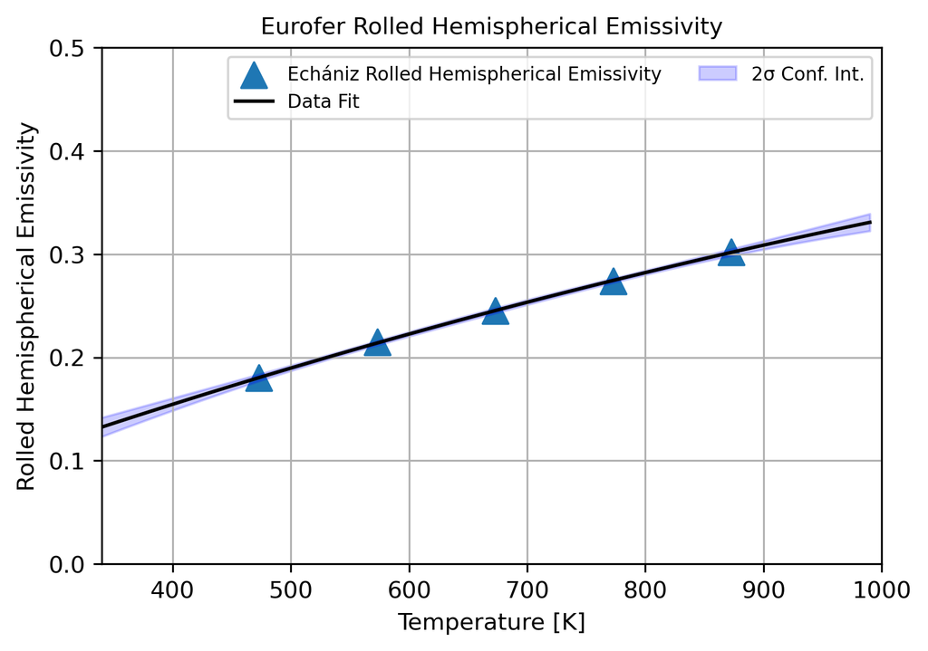

```python
material_property = "Emissivity"
var_names, variables, dataframe = load_data(excel_filename, material_property, header_rows_list=[1, 3], num_data_rows=5)
x_label = 'Temperature [K]'
y_label = r'Rolled Hemispherical Emissivity'
x_lim=[340, 1000]
y_lim=[0, 0.5]
data_labels = ['Echániz Rolled Hemispherical Emissivity']
display(Markdown('Data source: [Echaniz2021](https://drive.google.com/file/d/1R--IcJwy-Frr6Qgmk2nLzMMtuwO5uZSP/view?usp=sharing)'))

vars_x = variables[::2]
vars_y = variables[1::2]

# Creating lists with only the first column
x_data_list = [vars_x[0]]
y_data_list = [vars_y[0]]
# Extract only the first element from vars_x and vars_y
T_data = x_data_list
Y_data = y_data_list
data_marker_sizes = [2*m_size] * len(x_data_list)

# Fit the data
p = [1, 1, 1]
fit_result = get_model_fit_and_print_it(T_data, Y_data, fit_func='poly', param_initials=p, method='leastsq',\
    material_name=material_name, property_name=material_property, eq_digits=4, print_bool=True)

plot_data(x_data_list, y_data_list, T, fit_result, f_size, data_marker_sizes,\
          x_label, y_label, x_lim, y_lim, data_labels,\
          'Eurofer Rolled Hemispherical Emissivity','best', legend_font_size= 8)

emit2_coeff = [fit_result.params[key].value for key in fit_result.params]  # Extract parameter values as a list

# Define the polynomial function
def RolledHemisphericalEmissivity(T):
    return sum(emit2_coeff[i] * T**i for i in range(len(emit2_coeff)))
```

|  | Echaniz2021AsrolledTempK | Echaniz2021AsrolledHemisphericalEmissivity | Echaniz2021PolishedTempK1 | Echaniz2021PolishedHemisphericalEmissivity1 | Echaniz2021polishedTempK2 | Echaniz2021polishedNormalEmissivity |
| --- | --- | --- | --- | --- | --- | --- |
| 0 | 473.100872 | 0.180080 | 430.136986 | 0.116901 | 423 | 0.083535 |
| 1 | 573.225405 | 0.214688 | 524.283935 | 0.128974 | 523 | 0.100909 |
| 2 | 672.976339 | 0.245272 | 624.034869 | 0.142656 | 623 | 0.120303 |
| 3 | 772.727273 | 0.273843 | 724.906600 | 0.156338 | 723 | 0.140707 |
| 4 | 872.851806 | 0.302012 | 820.921544 | 0.176459 | 823 | 0.162929 |

Data source: [Echaniz2021](https://drive.google.com/file/d/1R--IcJwy-Frr6Qgmk2nLzMMtuwO5uZSP/view?usp=sharing)

**Fitting parameters for Eurofer Emissivity**

```
[[Model]]
    Model(polynomial)
[[Fit Statistics]]
    # fitting method   = leastsq
    # function evals   = 13
    # data points      = 5
    # variables        = 3
    chi-square         = 5.0657e-06
    reduced chi-square = 2.5329e-06
    Akaike info crit   = -63.0122378
    Bayesian info crit = -64.1839240
[[Variables]]
    c0:  0.09421098 +/- 0.01702700 (18.07%) (init = 1)
    c1:  4.0998e-06 +/- 5.6421e-05 (1376.18%) (init = 1)
    c2:  1.1591e-07 +/- 4.4909e-08 (38.75%) (init = 2)
[[Correlations]] (unreported correlations are < 0.100)
    C(c1, c2) = -0.9959
    C(c0, c1) = -0.9943
    C(c0, c2) = +0.9813
```

**The equation for Eurofer Emissivity is:**

$\boxed{ + 9.421 \cdot 10^{-2} + 4.1 \cdot 10^{-6} T + 1.159 \cdot 10^{-7} T^{2} }$

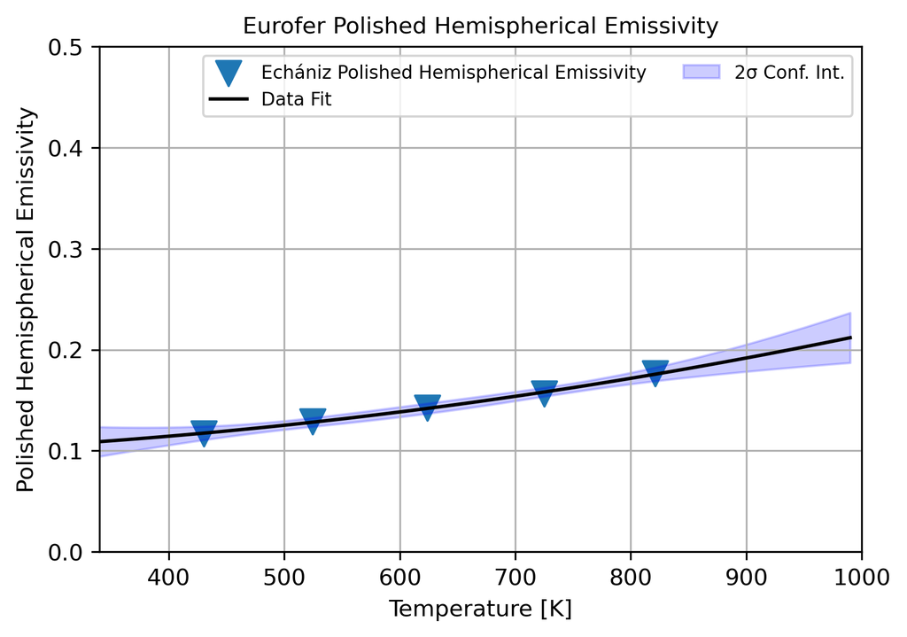

```python
material_property = "Emissivity"
var_names, variables, dataframe = load_data(excel_filename, material_property, header_rows_list=[1, 3], num_data_rows=5)
x_label = 'Temperature [K]'
y_label = r'Polished Hemispherical Emissivity'
x_lim=[340, 1000]
y_lim=[0, 0.5]
data_labels = ['Echániz Polished Hemispherical Emissivity']
display(Markdown('Data source: [Echaniz2021](https://drive.google.com/file/d/1R--IcJwy-Frr6Qgmk2nLzMMtuwO5uZSP/view?usp=sharing)'))

vars_x = variables[::2]
vars_y = variables[1::2]

# Creating lists with only the first column
x_data_list = [vars_x[1]]
y_data_list = [vars_y[1]]
# Extract only the first element from vars_x and vars_y
T_data = x_data_list
Y_data = y_data_list
data_marker_sizes = [2*m_size] * len(x_data_list)

# Fit the data
p = [1, 1, 1]
fit_result = get_model_fit_and_print_it(T_data, Y_data, fit_func='poly', param_initials=p, method='leastsq',\
    material_name=material_name, property_name=material_property, eq_digits=4, print_bool=True)

plot_data(x_data_list, y_data_list, T, fit_result, f_size, data_marker_sizes,\
          x_label, y_label, x_lim, y_lim, data_labels,\
          'Eurofer Polished Hemispherical Emissivity','best', legend_font_size= 8)

emit3_coeff = [fit_result.params[key].value for key in fit_result.params]  # Extract parameter values as a list

# Define the polynomial function
def PolishedHemisphericalEmissivity(T):
    return sum(emit3_coeff[i] * T**i for i in range(len(emit3_coeff)))
```

### 2.8. Elastic Properties

|  | Tavassoli2002TempK | Tavassoli2002EGpa | Tavassoli20021TempK1 | Tavassoli20021GGpa |
| --- | --- | --- | --- | --- |
| 0 | 374.766974 | 215.900179 | 375.654306 | 83.230301 |
| 1 | 412.109950 | 215.876805 | 412.453247 | 81.215235 |
| 2 | 474.554014 | 212.849671 | 474.310642 | 82.570939 |
| 3 | 540.898251 | 210.019299 | 541.765598 | 80.337482 |
| 4 | 603.342315 | 206.992166 | 601.968239 | 79.104580 |
| 5 | 668.562510 | 205.556920 | 668.859175 | 77.867491 |
| 6 | 732.687974 | 201.134312 | 729.069811 | 75.439365 |
| 7 | 793.453303 | 199.104245 | 793.715328 | 76.594121 |
| 8 | 858.121469 | 196.872532 | 857.256787 | 76.155942 |
| 9 | NaN | NaN | 920.804908 | 74.721742 |
| 10 | NaN | NaN | 979.910155 | 70.899886 |
| 11 | NaN | NaN | 1044.574324 | 69.265785 |
| 12 | NaN | NaN | 1108.683800 | 67.233625 |
| 13 | NaN | NaN | 1172.253239 | 62.612161 |
| 14 | NaN | NaN | 1232.462542 | 60.383239 |

**Fitting parameters for Eurofer Elastic Properties**

```
[[Model]]
    Model(polynomial)
[[Fit Statistics]]
    # fitting method   = leastsq
    # function evals   = 16
    # data points      = 9
    # variables        = 4
    chi-square         = 2.31309473
    reduced chi-square = 0.46261895
    Akaike info crit   = -4.22774415
    Bayesian info crit = -3.43884584
[[Variables]]
    c0:  211.235958 +/- 17.6216000 (8.34%) (init = 1)
    c1:  0.06666268 +/- 0.09204520 (138.08%) (init = 1)
    c2: -1.7655e-04 +/- 1.5419e-04 (87.33%) (init = 1)
    c3:  9.2402e-08 +/- 8.3227e-08 (90.07%) (init = 3)
[[Correlations]] (unreported correlations are < 0.100)
    C(c2, c3) = -0.9977
    C(c1, c2) = -0.9973
    C(c0, c1) = -0.9969
    C(c1, c3) = +0.9900
    C(c0, c2) = +0.9887
    C(c0, c3) = -0.9768
```

**The equation for Eurofer Elastic Properties is:**

$\boxed{ + 2.112 \cdot 10^{2} + 6.666 \cdot 10^{-2} T - 1.766 \cdot 10^{-4} T^{2} + 9.24 \cdot 10^{-8} T^{3} }$

Data source: [Tavassoli2002](https://drive.google.com/file/d/1Nsoesbbd3rxN5FvH4YHBmJVacFU83ctA/view?usp=drive_link)

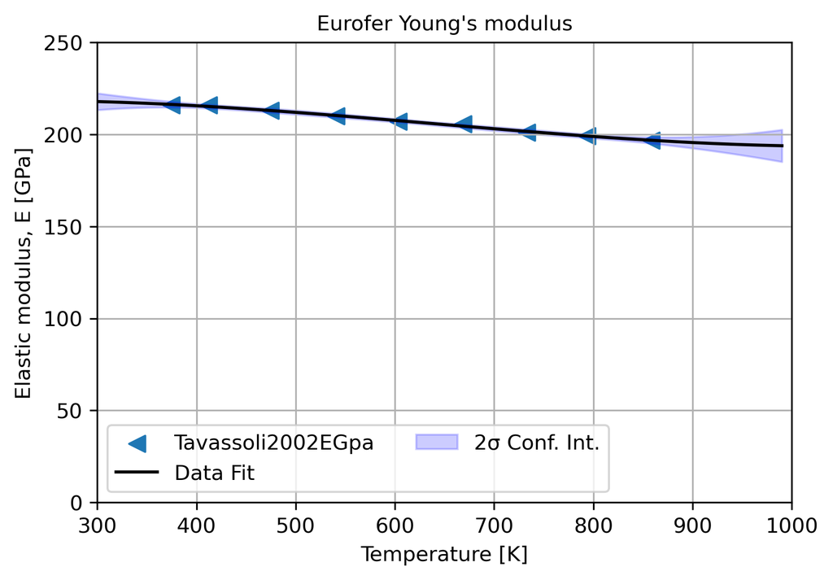

```python
material_property = "Elastic Properties"
var_names, variables, df = load_data(excel_filename, material_property, header_rows_list=[1, 3], num_data_rows=18)
x_label = 'Temperature [K]'
y_label = 'Elastic modulus, E [GPa]'
x_lim=[300, 1000]
y_lim=[0, 250]
headings = df.columns
data_labels = [headings[1]]
df = df[['Tavassoli2002TempK', 'Tavassoli2002EGpa']].dropna()

# Convert to lists
T_data = [df['Tavassoli2002TempK'].tolist()]
Y_data = [df['Tavassoli2002EGpa'].tolist()]

data_marker_sizes = [m_size] * len(T_data)

# Fit the data
p = [1, 1, 1, 1]
fit_result = get_model_fit_and_print_it(T_data, Y_data, fit_func='poly', param_initials=p, method='leastsq',\
    material_name=material_name, property_name=material_property, eq_digits=4, print_bool=True)

plot_data(T_data, Y_data, T, fit_result, f_size, data_marker_sizes, x_label, y_label, x_lim, y_lim, data_labels,\
          "Eurofer Young's modulus",'best', legend_font_size= 10)

Young_coeff = [fit_result.params[key].value for key in fit_result.params]  # Extract parameter values as a list

# Define the polynomial function
def YoungsModulus(T):
    return sum(Young_coeff[i] * T**i for i in range(len(Young_coeff)))


display(Markdown('Data source: [Tavassoli2002](https://drive.google.com/file/d/1Nsoesbbd3rxN5FvH4YHBmJVacFU83ctA/view?usp=drive_link)'))
```

|  | Tavassoli2002TempK | Tavassoli2002EGpa | Tavassoli20021TempK1 | Tavassoli20021GGpa |
| --- | --- | --- | --- | --- |
| 0 | 374.766974 | 215.900179 | 375.654306 | 83.230301 |
| 1 | 412.109950 | 215.876805 | 412.453247 | 81.215235 |
| 2 | 474.554014 | 212.849671 | 474.310642 | 82.570939 |
| 3 | 540.898251 | 210.019299 | 541.765598 | 80.337482 |
| 4 | 603.342315 | 206.992166 | 601.968239 | 79.104580 |
| 5 | 668.562510 | 205.556920 | 668.859175 | 77.867491 |
| 6 | 732.687974 | 201.134312 | 729.069811 | 75.439365 |
| 7 | 793.453303 | 199.104245 | 793.715328 | 76.594121 |
| 8 | 858.121469 | 196.872532 | 857.256787 | 76.155942 |
| 9 | NaN | NaN | 920.804908 | 74.721742 |
| 10 | NaN | NaN | 979.910155 | 70.899886 |
| 11 | NaN | NaN | 1044.574324 | 69.265785 |
| 12 | NaN | NaN | 1108.683800 | 67.233625 |
| 13 | NaN | NaN | 1172.253239 | 62.612161 |
| 14 | NaN | NaN | 1232.462542 | 60.383239 |

**Fitting parameters for Eurofer Elastic Properties**

```
[[Model]]
    Model(polynomial)
[[Fit Statistics]]
    # fitting method   = leastsq
    # function evals   = 16
    # data points      = 15
    # variables        = 4
    chi-square         = 12.1647372
    reduced chi-square = 1.10588520
    Akaike info crit   = 4.85736759
    Bayesian info crit = 7.68956840
[[Variables]]
    c0:  99.4282565 +/- 8.24331893 (8.29%) (init = 1)
    c1: -0.07045636 +/- 0.03495370 (49.61%) (init = 1)
    c2:  8.9755e-05 +/- 4.6029e-05 (51.28%) (init = 1)
    c3: -4.7574e-08 +/- 1.9068e-08 (40.08%) (init = 3)
[[Correlations]] (unreported correlations are < 0.100)
    C(c2, c3) = -0.9957
    C(c1, c2) = -0.9943
    C(c0, c1) = -0.9920
    C(c1, c3) = +0.9804
    C(c0, c2) = +0.9740
    C(c0, c3) = -0.9511
```

**The equation for Eurofer Elastic Properties is:**

$\boxed{ + 9.943 \cdot 10^{1} - 7.046 \cdot 10^{-2} T + 8.975 \cdot 10^{-5} T^{2} - 4.757 \cdot 10^{-8} T^{3} }$

Data source: [Tavassoli2002](https://drive.google.com/file/d/1Nsoesbbd3rxN5FvH4YHBmJVacFU83ctA/view?usp=drive_link)

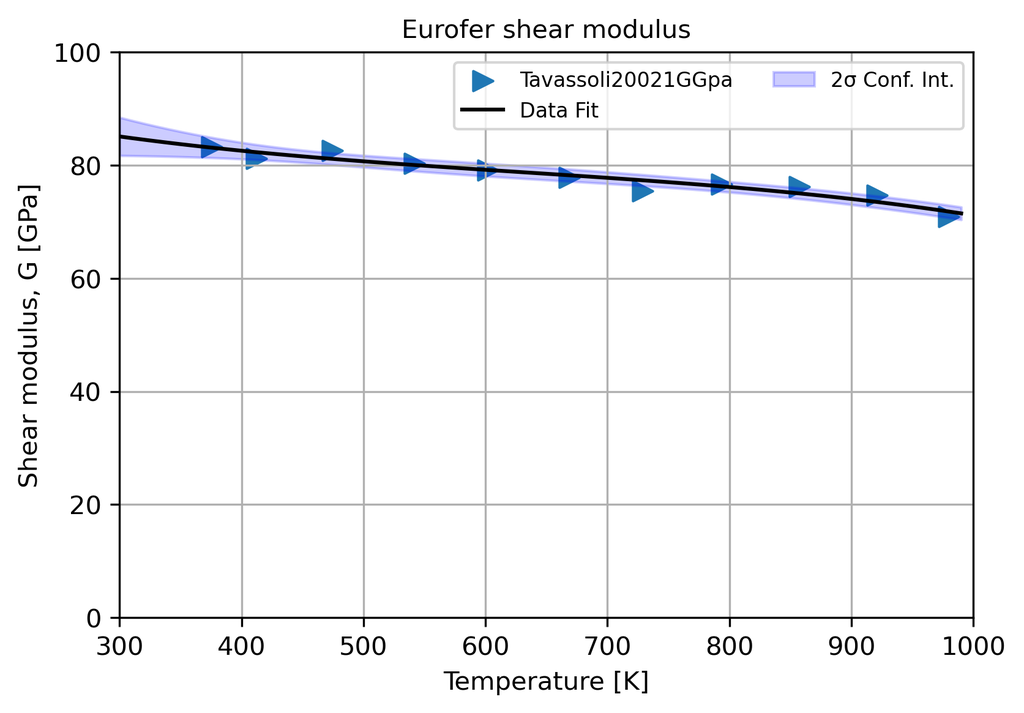

```python
material_property = "Elastic Properties"
x_label = 'Temperature [K]'
y_label = 'Shear modulus, G [GPa]'
x_lim=[300, 1000]
y_lim=[0, 100]

var_names, variables, df = load_data(excel_filename, material_property, header_rows_list=[1, 3], num_data_rows=18)
headings = df.columns
data_labels = [headings[3]]

SelectedFrame = df[['Tavassoli20021TempK1', 'Tavassoli20021GGpa']].dropna()
# Convert to lists
T_data = [SelectedFrame['Tavassoli20021TempK1'].tolist()]
Y_data = [SelectedFrame['Tavassoli20021GGpa'].tolist()]

data_marker_sizes = [m_size] * len(T_data)

# Fit the data
p = [1, 1, 1, 1]
fit_result = get_model_fit_and_print_it(T_data, Y_data, fit_func='poly', param_initials=p, method='leastsq',\
    material_name=material_name, property_name=material_property, eq_digits=4, print_bool=True)

plot_data(T_data, Y_data, T, fit_result, f_size, data_marker_sizes, x_label, y_label, x_lim, y_lim, \
          data_labels,'Eurofer shear modulus','best', legend_font_size= 8)

display(Markdown('Data source: [Tavassoli2002](https://drive.google.com/file/d/1Nsoesbbd3rxN5FvH4YHBmJVacFU83ctA/view?usp=drive_link)'))

Shear_Coeff = [fit_result.params[key].value for key in fit_result.params]  # Extract parameter values as a list

# Define the polynomial function
def ShearModulus(T):
    return sum(Shear_Coeff[i] * T**i for i in range(len(Shear_Coeff)))
```

### 2.9. Hardness

|  | Schaefer2000Heat993391_1040CTemperingTempC | Schaefer2000Heat993391_1040CHardness | Schaefer2000Heat993402_1040CTemperingTempC1 | Schaefer2000Heat993402_1040CHardness1 | Schaefer2000Heat993391_980CTemperingTempC2 | Schaefer2000Heat993391_980CHardness2 | Schaefer2000Heat993402_980CTemperingTempC3 | Schaefer2000Heat993402_980CHardness3 |
| --- | --- | --- | --- | --- | --- | --- | --- | --- |
| 0 | 20 | 410.294118 | 20 | 410.294118 | 20.0 | 409.637255 | 20.0 | 420.225490 |
| 1 | 650 | 310.539216 | 650 | 309.803922 | 650.0 | 305.166667 | 650.0 | 300.225490 |
| 2 | 700 | 264.705882 | 700 | 260.049020 | 700.0 | 264.578431 | 700.0 | 255.049020 |
| 3 | 725 | 237.745098 | 750 | 204.901961 | 750.0 | 214.460784 | 750.0 | 210.225490 |
| 4 | 775 | 204.656863 | 800 | 195.098039 | 800.0 | 199.990196 | 800.0 | 199.990196 |
| 5 | 825 | 234.803922 | 825 | 179.656863 | 825.0 | 225.049020 | 825.0 | 202.813725 |
| 6 | 850 | 299.509804 | 850 | 364.705882 | 850.0 | 389.872549 | 850.0 | 394.813725 |
| 7 | 950 | 410.294118 | 950 | 414.950980 | 900.0 | 405.401961 | 900.0 | 410.343137 |
| 8 | 1000 | 415.196078 | 1000 | 419.852941 | NaN | NaN | NaN | NaN |
| 9 | 1050 | 410.539216 | 1050 | 417.156863 | NaN | NaN | NaN | NaN |
| 10 | 1100 | 405.147059 | 1100 | 414.705882 | NaN | NaN | NaN | NaN |
| 11 | 1150 | 390.196078 | 1150 | 394.852941 | NaN | NaN | NaN | NaN |

**Fitting parameters for Eurofer Hardness**

```
[[Model]]
    Model(dip)
[[Fit Statistics]]
    # fitting method   = leastsq
    # function evals   = 193
    # data points      = 40
    # variables        = 7
    chi-square         = 9002.37220
    reduced chi-square = 272.799157
    Akaike info crit   = 230.654558
    Bayesian info crit = 242.476714
    R-squared          = 0.97083630
[[Variables]]
    p_0:  646.724607 +/- 25.5954612 (3.96%) (init = 100)
    p_1: -117.117981 +/- 11.9622325 (10.21%) (init = 400)
    p_2:  1114.23278 +/- 1.88561362 (0.17%) (init = 1100)
    p_3: -14.7822164 +/- 3.09121452 (20.91%) (init = 50)
    p_4: -119.371048 +/- 13.3461748 (11.18%) (init = -200)
    p_5:  937.327284 +/- 13.8846056 (1.48%) (init = 800)
    p_6:  114.530458 +/- 32.8367125 (28.67%) (init = 100)
[[Correlations]] (unreported correlations are < 0.100)
    C(p_0, p_4) = -0.9820
    C(p_0, p_1) = -0.9466
    C(p_1, p_4) = +0.9308
    C(p_4, p_6) = -0.8740
    C(p_1, p_6) = -0.8666
    C(p_0, p_6) = +0.8445
    C(p_1, p_5) = -0.8342
    C(p_1, p_3) = +0.7644
    C(p_0, p_3) = -0.7203
    C(p_3, p_4) = +0.7156
    C(p_4, p_5) = -0.7145
    C(p_0, p_5) = +0.6966
    C(p_3, p_5) = -0.6652
    C(p_5, p_6) = +0.6317
    C(p_3, p_6) = -0.5969
    C(p_2, p_3) = +0.5656
    C(p_2, p_5) = -0.4524
    C(p_2, p_4) = +0.4282
    C(p_1, p_2) = +0.4118
    C(p_0, p_2) = -0.3805
    C(p_2, p_6) = -0.2305
```

**The equation for Eurofer Hardness is:**

$\boxed{ + 646.7 + 117.1 \tanh{\left(0.06765 T - 75.38 \right)} - 117.1- 119.4 \tanh{\left(0.008731 T - 8.184 \right)} - 119.4 }$

Data source: [Schaefer2000](https://drive.google.com/file/d/1SU0uSAMExpNDlM0tSGPHX0O3RnZh3d3g/view?usp=drive_link)

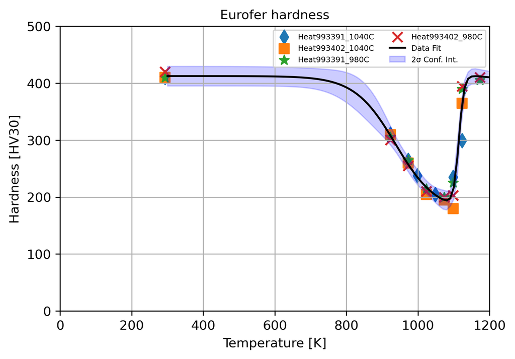

```python
material_property = "Hardness"
var_names, variables, dataframe = load_data(excel_filename, material_property, header_rows_list=[1, 3], num_data_rows=12)
x_label = 'Temperature [K]'
y_label = 'Hardness [HV30]'
x_lim=[0, 1200]
y_lim=[0, 500]
data_labels = ['Heat993391_1040C','Heat993402_1040C','Heat993391_980C','Heat993402_980C']

#Concatenate and sort data for fitting
vars_x = [RT + x for x in variables[::2]]
vars_y = variables[1::2]
T_data, Y_data = concatenate_and_sort(vars_x, vars_y)
x_data_list = [x for x in vars_x]
y_data_list = vars_y
data_marker_sizes = [m_size] * len(x_data_list)
T = np.arange(300, 1300, 10)
n = len(T)
# Fit the data
p = [100,400,1100,50,-200,800,100]
fit_result = get_model_fit_and_print_it(T_data, Y_data, fit_func='dip', param_initials=p, method='leastsq',\
    material_name=material_name, property_name=material_property, eq_digits=4, print_bool=True)

plot_data(x_data_list, y_data_list, T, fit_result, f_size, data_marker_sizes, x_label, y_label, x_lim, y_lim, data_labels,\
          'Eurofer hardness','best', legend_font_size= 6)


display(Markdown('Data source: [Schaefer2000](https://drive.google.com/file/d/1SU0uSAMExpNDlM0tSGPHX0O3RnZh3d3g/view?usp=drive_link)'))

Hardness_coeff = [fit_result.params[key].value for key in fit_result.params]  # Extract parameter values as a list

# Define the polynomial function
def Hardness(T):
    return Hardness_coeff[0] + Hardness_coeff[1]* (1 + np.tanh((T - Hardness_coeff[2]) / Hardness_coeff[3]))\
    + Hardness_coeff[4] * (1 + np.tanh((T - Hardness_coeff[5]) / Hardness_coeff[6]))
```

### 2.10. Yield Strength

|  | Chun2015TempC | Chun2015YieldStrengthMPa | Aillo2011TempC1 | Aillo2011YieldStrengthMPa1 | Rieth2003979C2h+739C4hTempC2 | Rieth2003979C2h+739C4hYieldStrengthMPa2 | Rieth20031075C05h+750C2hTC | Rieth20031075C05h+750C2hYieldStrengthMPa3 | Rieth2003980C27min+760C90minTempC3 | Rieth2003980C27min+760C90minYieldStrengthMPa4 | Rieth20031075C30min+750C2hTempC4 | Rieth20031075C30min+750C2hYieldStrengthMPa5 | Rieth2003950C30min+750C2hTempC5 | Rieth2003950C30min+750C2hYieldStrengthMPa6 | Rieth2003600C1050hTempC6 | Rieth2003600C1050hYieldStrengthMPa7 | Rieth2003580C3300hTempC7 | Rieth2003580C3300hYieldStrengthMPa8 | Rieth20031075C+750C+600C1050hTempC8 | Rieth20031075C+750C+600C1050hYieldStrengthMPa9 |
| --- | --- | --- | --- | --- | --- | --- | --- | --- | --- | --- | --- | --- | --- | --- | --- | --- | --- | --- | --- | --- |
| 0 | 20 | 547.858099 | 20.0 | 511.72884 | 18.947368 | 570.967742 | 18.947368 | 518.433180 | 18.947368 | 539.170507 | 11.052632 | 529.493088 | 17.894737 | 495.622120 | 19.444444 | 549.305556 | 18.888889 | 536.111111 | 28.333333 | 509.722222 |
| 1 | 50 | 525.368139 | 100.0 | 476.28520 | 300.762195 | 476.306620 | 300.076220 | 456.794425 | 308.307927 | 465.156794 | 287.728659 | 463.763066 | 301.448171 | 435.888502 | 309.954058 | 469.068541 | 385.068913 | 450.087873 | 298.928025 | 438.840070 |
| 2 | 100 | 508.768407 | 150.0 | 461.81125 | 400.228659 | 454.703833 | 400.228659 | 443.554007 | 391.310976 | 437.282230 | 406.402439 | 435.191638 | 400.914634 | 410.104530 | 411.944870 | 452.899824 | 489.816233 | 398.066784 | 398.162328 | 421.265378 |
| 3 | 150 | 494.846051 | 200.0 | 452.56896 | 502.439024 | 405.923345 | 502.439024 | 389.198606 | 493.521341 | 396.864111 | 515.472561 | 393.379791 | 504.496951 | 375.958188 | 509.800919 | 400.878735 | NaN | NaN | 509.111792 | 380.492091 |
| 4 | 200 | 486.278447 | 250.0 | 445.93818 | 604.649390 | 283.972125 | 603.963415 | 274.912892 | 616.996951 | 277.700348 | 592.301829 | 277.700348 | 606.021341 | 257.491289 | 613.169985 | 284.182777 | NaN | NaN | 613.169985 | 270.123023 |
| 5 | 250 | 479.317269 | 300.0 | 436.69732 | 703.429878 | 132.752613 | NaN | NaN | NaN | NaN | NaN | NaN | NaN | NaN | NaN | NaN | NaN | NaN | NaN | NaN |
| 6 | 300 | 471.820616 | 350.0 | 427.45072 | NaN | NaN | NaN | NaN | NaN | NaN | NaN | NaN | NaN | NaN | NaN | NaN | NaN | NaN | NaN | NaN |
| 7 | 350 | 462.717537 | 400.0 | 410.36382 | NaN | NaN | NaN | NaN | NaN | NaN | NaN | NaN | NaN | NaN | NaN | NaN | NaN | NaN | NaN | NaN |
| 8 | 400 | 448.795181 | 450.0 | 388.04959 | NaN | NaN | NaN | NaN | NaN | NaN | NaN | NaN | NaN | NaN | NaN | NaN | NaN | NaN | NaN | NaN |
| 9 | 450 | 427.376171 | 500.0 | 353.96629 | NaN | NaN | NaN | NaN | NaN | NaN | NaN | NaN | NaN | NaN | NaN | NaN | NaN | NaN | NaN | NaN |
| 10 | 500 | 397.925033 | 550.0 | 310.73839 | NaN | NaN | NaN | NaN | NaN | NaN | NaN | NaN | NaN | NaN | NaN | NaN | NaN | NaN | NaN | NaN |
| 11 | 550 | 355.622490 | 600.0 | 253.12703 | NaN | NaN | NaN | NaN | NaN | NaN | NaN | NaN | NaN | NaN | NaN | NaN | NaN | NaN | NaN | NaN |
| 12 | 600 | 299.933066 | 650.0 | 178.52503 | NaN | NaN | NaN | NaN | NaN | NaN | NaN | NaN | NaN | NaN | NaN | NaN | NaN | NaN | NaN | NaN |
| 13 | 650 | 228.179384 | 700.0 | 81.69784 | NaN | NaN | NaN | NaN | NaN | NaN | NaN | NaN | NaN | NaN | NaN | NaN | NaN | NaN | NaN | NaN |
| 14 | 700 | 137.148594 | NaN | NaN | NaN | NaN | NaN | NaN | NaN | NaN | NaN | NaN | NaN | NaN | NaN | NaN | NaN | NaN | NaN | NaN |

Data sources: [Rieth2003](https://drive.google.com/file/d/1RAZvEfS86f9VIa6HI1LbvRLpuwSAl8jf/view?usp=sharing), [Aillo2011](https://drive.google.com/file/d/1QlfT7DE8DbNop-vl-J2oJIgUBri_-q7l/view?usp=drive_link)

**Fitting parameters for Eurofer Yield Strength**

```
[[Model]]
    Model(polynomial)
[[Fit Statistics]]
    # fitting method   = leastsq
    # function evals   = 16
    # data points      = 68
    # variables        = 4
    chi-square         = 23033.6829
    reduced chi-square = 359.901295
    Akaike info crit   = 404.113953
    Bayesian info crit = 412.991984
    R-squared          = 0.96991591
[[Variables]]
    c0:  1004.42873 +/- 65.6861244 (6.54%) (init = 1)
    c1: -2.86326940 +/- 0.37128450 (12.97%) (init = 1)
    c2:  0.00523191 +/- 6.3785e-04 (12.19%) (init = 1)
    c3: -3.3172e-06 +/- 3.4175e-07 (10.30%) (init = 3)
[[Correlations]] (unreported correlations are < 0.100)
    C(c2, c3) = -0.9962
    C(c1, c2) = -0.9950
    C(c0, c1) = -0.9918
    C(c1, c3) = +0.9829
    C(c0, c2) = +0.9756
    C(c0, c3) = -0.9554
```

**The equation for Eurofer Yield Strength is:**

$\boxed{ + 1.004 \cdot 10^{3} - 2.863 T + 5.232 \cdot 10^{-3} T^{2} - 3.317 \cdot 10^{-6} T^{3} }$

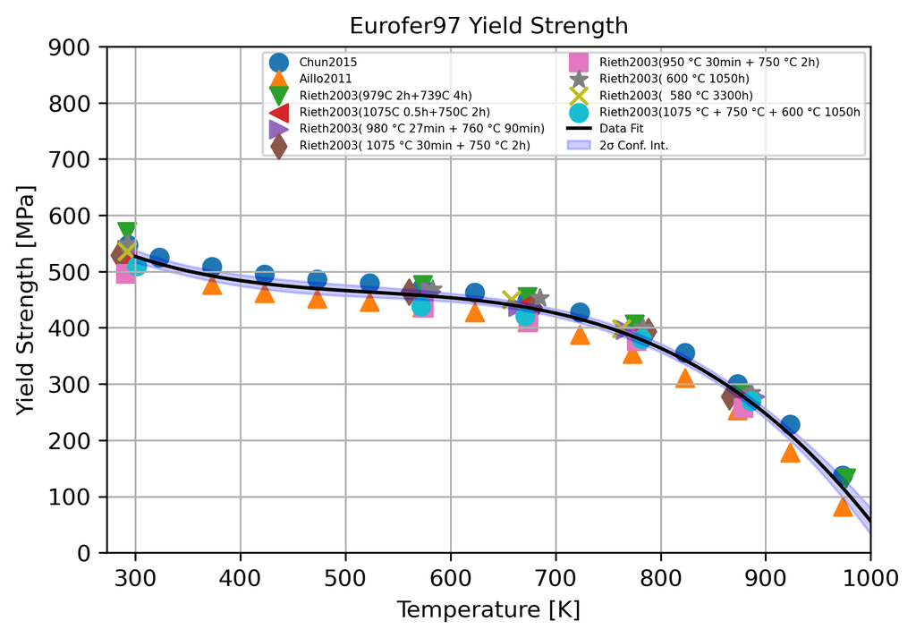

```python
material_property = "Yield Strength"
var_names, variables, dataframe = load_data(excel_filename, material_property, header_rows_list=[1, 3], num_data_rows=15)
x_label = 'Temperature [K]'
y_label = 'Yield Strength [MPa]'
x_lim=[RT, 1000]
y_lim=[0, 900]
data_labels = ['Chun2015','Aillo2011','Rieth2003(979C 2h+739C 4h)','Rieth2003(1075C 0.5h+750C 2h)','Rieth2003( 980 °C 27min + 760 °C 90min)',
'Rieth2003( 1075 °C 30min + 750 °C 2h)','Rieth2003(950 °C 30min + 750 °C 2h)','Rieth2003( 600 °C 1050h)','Rieth2003(  580 °C 3300h)',
'Rieth2003(1075 °C + 750 °C + 600 °C 1050h']

display(Markdown('Data sources: [Rieth2003](https://drive.google.com/file/d/1RAZvEfS86f9VIa6HI1LbvRLpuwSAl8jf/view?usp=sharing), \
[Aillo2011](https://drive.google.com/file/d/1QlfT7DE8DbNop-vl-J2oJIgUBri_-q7l/view?usp=drive_link)'))

#Concatenate and sort data for fitting
vars_x = [RT + x for x in variables[::2]]
vars_y = variables[1::2]
T_data, Y_data = concatenate_and_sort(vars_x, vars_y)
x_data_list = [x for x in vars_x]
y_data_list = vars_y
data_marker_sizes = [m_size] * len(x_data_list)

# Fit the data
p = [1, 1, 1, 1]
fit_result = get_model_fit_and_print_it(T_data, Y_data, fit_func='poly', param_initials=p, method='leastsq',\
    material_name=material_name, property_name=material_property, eq_digits=4, print_bool=True)

plot_data(x_data_list, y_data_list, T, fit_result, f_size, data_marker_sizes,\
          x_label, y_label, x_lim, y_lim, data_labels,\
          'Eurofer97 Yield Strength','best', legend_font_size=5)

Yield_coeff = [fit_result.params[key].value for key in fit_result.params]  # Extract parameter values as a list

# Define the polynomial function
def YieldStrength(T):
    return sum(Yield_coeff[i] * T**i for i in range(len(Yield_coeff)))
```